# machine learning project

christian

27 December 2015

## Background

Using devices such as Jawbone Up, Nike FuelBand, and Fitbit it is now possible to collect a large amount of data about personal activity relatively inexpensively. These type of devices are part of the quantified self movement – a group of enthusiasts who take measurements about themselves regularly to improve their health, to find patterns in their behavior, or because they are tech geeks. One thing that people regularly do is quantify how much of a particular activity they do, but they rarely quantify how well they do it. In this project, your goal will be to use data from accelerometers on the belt, forearm, arm, and dumbell of 6 participants. They were asked to perform barbell lifts correctly and incorrectly in 5 different ways. More information is available from the website here: http://groupware.les.inf.puc.rio.br/har (see the section on the Weight Lifting Exercise Dataset).

## Introduction

The goal of this project is to predict the manner in which they did the exercise. This is the “classe” variable in the training set. All the other variables, which were left after cleaning, were used to predict. The data can be found here:

| set | link |
| --- | --- |
| test | https://d396qusza40orc.cloudfront.net/predmachlearn/pml-testing.csv |
| train | https://d396qusza40orc.cloudfront.net/predmachlearn/pml-training.csv |

# Loading and cleaning data

The two sets are saved as training and testing2. Next step is to clean the sets, i.e. the dates are transformed to the posixct format and all columns containing NA’s are removed.

```r
## load packages

library(ggplot2)
library(caret)
library(randomForest)
library(rattle)
## load data

training <- read.csv("../pml-training1.csv", header = TRUE, sep = ",", na.strings=c("NA","#DIV/0!",""))
testing2 <- read.csv("../pml-testing.csv", header = TRUE, sep = ",", na.strings=c("NA","#DIV/0!",""))

## change date format

training$cvtd_timestamp <- as.POSIXct(training$cvtd_timestamp, format = "%d/%m/%Y %H:%M", tz = "America/Sao_Paulo")
testing2$cvtd_timestamp <- as.POSIXct(testing2$cvtd_timestamp, format = "%d/%m/%Y %H:%M", tz = "America/Sao_Paulo")

## remove all columns with NA's

training <- training[, colSums(is.na(training)) == 0]
training <- training[, -1]
training <- training[, -5]
testing2 <- testing2[, which(names(testing2) %in% names(training))]
```

As next we create a training and test set.

```r
## create training and test set
set.seed(15132)

inTrain <- createDataPartition(y = training$classe, p = 0.7, list = FALSE)
training <- training[inTrain,]
testing <- training[-inTrain,]
```

# Model selection

First we try a simple classification model (rpart). When we take the test set for prediction and create a confusion matrix we see that this model performs quite badly. Therefore we will create a second model using random forest.

```r
## first model
modFit <- train(classe ~., method = "rpart", data = training)
print(modFit$finalModel)
```

```
## n= 13737
##
## node), split, n, loss, yval, (yprob)
##       * denotes terminal node
##
##  1) root 13737 9831 A (0.28 0.19 0.17 0.16 0.18)
##    2) roll_belt< 130.5 12584 8691 A (0.31 0.21 0.19 0.18 0.11)
##      4) pitch_forearm< -34.35 1100    4 A (1 0.0036 0 0 0) *
##      5) pitch_forearm>=-34.35 11484 8687 A (0.24 0.23 0.21 0.2 0.12)
##       10) num_window>=45.5 10969 8172 A (0.25 0.24 0.22 0.2 0.088)
##         20) num_window< 241.5 2492 1137 A (0.54 0.12 0.11 0.19 0.047) *
##         21) num_window>=241.5 8477 6116 B (0.17 0.28 0.25 0.2 0.1)
##           42) magnet_dumbbell_z< -24.5 2336 1252 A (0.46 0.35 0.051 0.12 0.012)
##             84) raw_timestamp_part_1< 1.322838e+09 860   51 A (0.94 0.055 0.0047 0 0) *
##             85) raw_timestamp_part_1>=1.322838e+09 1476  703 B (0.19 0.52 0.078 0.19 0.02) *
##           43) magnet_dumbbell_z>=-24.5 6141 4126 C (0.058 0.25 0.33 0.23 0.13)
##             86) magnet_dumbbell_x>=-445.5 1766  937 B (0.044 0.47 0.058 0.17 0.25) *
##             87) magnet_dumbbell_x< -445.5 4375 2463 C (0.064 0.16 0.44 0.25 0.084) *
##       11) num_window< 45.5 515   92 E (0 0 0 0.18 0.82) *
##    3) roll_belt>=130.5 1153   13 E (0.011 0 0 0 0.99) *
```

```r
pred <- predict(modFit, newdata = testing)
confusionMatrix(pred, testing$classe)
```

```
## Confusion Matrix and Statistics
##
##           Reference
## Prediction   A   B   C   D   E
##          A 967 103  79 127  35
##          B 104 505  76 174 148
##          C  80 208 578 331 120
##          D   0   0   0   0   0
##          E   5   0   0  19 480
##
## Overall Statistics
##
##                Accuracy : 0.6113
##                  95% CI : (0.5962, 0.6261)
##     No Information Rate : 0.2793
##     P-Value [Acc > NIR] : < 2.2e-16
##
##                   Kappa : 0.5043
##  Mcnemar's Test P-Value : < 2.2e-16
##
## Statistics by Class:
##
##                      Class: A Class: B Class: C Class: D Class: E
## Sensitivity            0.8365   0.6189   0.7885   0.0000   0.6130
## Specificity            0.8847   0.8489   0.7830   1.0000   0.9928
## Pos Pred Value         0.7376   0.5015   0.4389      NaN   0.9524
## Neg Pred Value         0.9332   0.9007   0.9451   0.8427   0.9166
## Prevalence             0.2793   0.1971   0.1771   0.1573   0.1892
## Detection Rate         0.2336   0.1220   0.1396   0.0000   0.1160
## Detection Prevalence   0.3167   0.2433   0.3182   0.0000   0.1218
## Balanced Accuracy      0.8606   0.7339   0.7858   0.5000   0.8029
```

```r
modFit3 <- randomForest(classe ~., data = training, ntree = 50)
pred3 <- predict(modFit3, newdata = testing, type = "class")
confusionMatrix(pred3, testing$classe)
```

```
## Confusion Matrix and Statistics
##
##           Reference
## Prediction    A    B    C    D    E
##          A 1156    0    0    0    0
##          B    0  816    0    0    0
##          C    0    0  733    0    0
##          D    0    0    0  651    0
##          E    0    0    0    0  783
##
## Overall Statistics
##
##                Accuracy : 1
##                  95% CI : (0.9991, 1)
##     No Information Rate : 0.2793
##     P-Value [Acc > NIR] : < 2.2e-16
##
##                   Kappa : 1
##  Mcnemar's Test P-Value : NA
##
## Statistics by Class:
##
##                      Class: A Class: B Class: C Class: D Class: E
## Sensitivity            1.0000   1.0000   1.0000   1.0000   1.0000
## Specificity            1.0000   1.0000   1.0000   1.0000   1.0000
## Pos Pred Value         1.0000   1.0000   1.0000   1.0000   1.0000
## Neg Pred Value         1.0000   1.0000   1.0000   1.0000   1.0000
## Prevalence             0.2793   0.1971   0.1771   0.1573   0.1892
## Detection Rate         0.2793   0.1971   0.1771   0.1573   0.1892
## Detection Prevalence   0.2793   0.1971   0.1771   0.1573   0.1892
## Balanced Accuracy      1.0000   1.0000   1.0000   1.0000   1.0000
```

As we can see the error rate falls fast under 0.01 with roughly 25 trees. Therefore we choose 50 trees and should get a good chance of predicting all 20 test cases right. There is a chance that we overpredicted our data since we get an accuracy of 1.

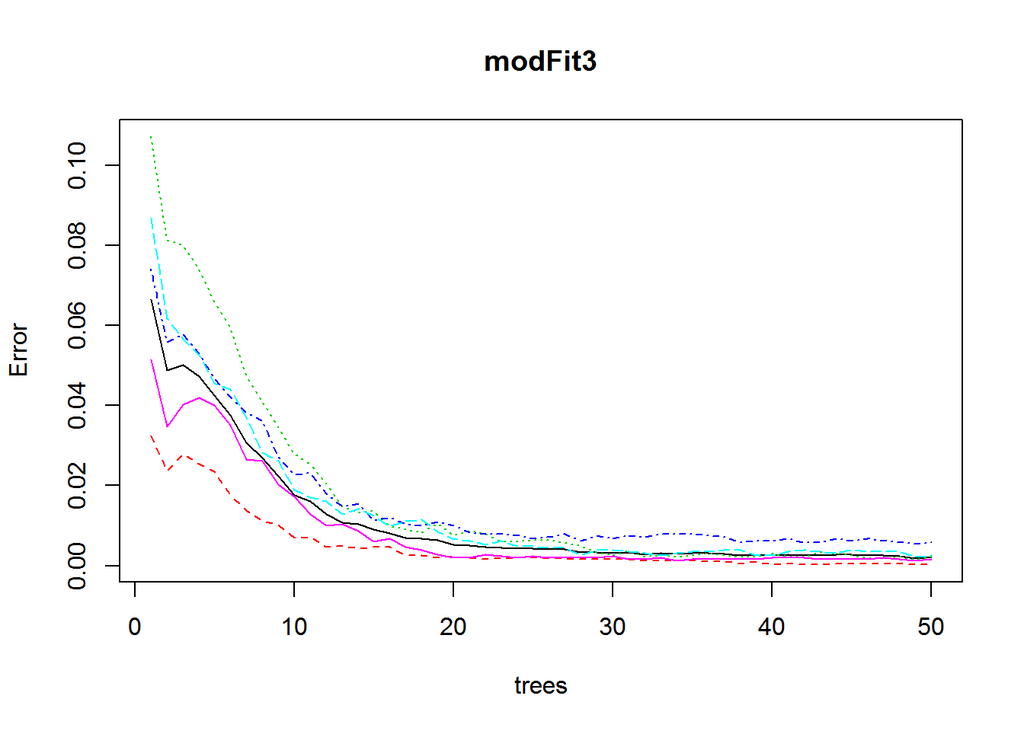

```r
plot(modFit3)
```

Overall we choose the random forest model for the test cases as our best model.